# KDD del dataset AgroCebada 2026: lectura de la fase de análisis de datos

Equipo Los Vochos · Reto AgroCebada FIRA 2026

# 1 Qué es este documento

Este informe recorre las etapas de un proceso KDD (selección, preprocesamiento, transformación, minería e interpretación) sobre el dataset del reto, con R. Es la lectura de la **fase 1** del repositorio. No entrena modelos: describe qué hay en los datos, qué tan confiable es cada fuente, cómo se relacionan las variables entre sí y con el rendimiento, y qué queda como candidato para la fase de modelos.

Todo lo que se muestra sale de los scripts de `analisis/datos_fira/R/`, ejecutados en orden. Las tablas y figuras están en `analisis/datos_fira/salida/`. Los datos oficiales de `DATASET_RETO_AGRO_2026/` no se modifican.

La etiqueta es el rendimiento del ciclo **abril–octubre de 2025**, visible en 138 parcelas de entrenamiento y oculta en 59 de predicción. Todas las correlaciones con el rendimiento usan solo esas 138.

# 2 Lo esencial

1. **La ubicación explica más del rendimiento que cualquier índice por separado.** Solo el estado explica cerca de 50 % de la varianza del rendimiento (R² ajustado) y el municipio cerca de 67 %. La mitad de las parcelas está en Chignahuapan.
2. **El clima “importa” sobre todo porque distingue estados.** La amplitud térmica del ciclo tiene ρ = -0.67 con el rendimiento, pero dentro de cada estado baja a -0.07. La lluvia del ciclo es distinta: conserva ρ = -0.38 dentro de cada estado.
3. **Los índices de vegetación del ciclo dan señal débil.** La mejor asociación univariada de Sentinel-2 ronda ρ ≈ 0.30 (integral de NDVI) y se debilita dentro de cada estado. Con nubosidad filtrada, la diferencia entre parcelas de alto y bajo rendimiento aparece al final del ciclo (septiembre–octubre), no en el máximo.
4. **El clima cubre las 197 parcelas con solo 25 píxeles.** Es una variable de zona, no de parcela.
5. **Hay mucha redundancia.** Las 88 variables candidatas se reducen a 45 grupos con |ρ| ≥ 0.90; 22 de esos grupos tienen varias variables casi idénticas, sobre todo en las familias de dosel y de humedad de Sentinel-2.
6. **Los perfiles de parcela que salen sin usar el rendimiento no lo separan.** Los grupos reflejan geografía y sensor, no productividad.

# 3 Selección

9 fuentes entran al análisis.

| Fuente | Unidad de observación | Filas o capas | Periodo | Uso |
| --- | --- | --- | --- | --- |
| Parcelas | parcela (polígono) | 197 | sin fecha | Geometría, área, municipio, estado, conjunto |
| Rendimiento | parcela | 197 | ciclo abr-oct 2025 | Etiqueta (solo 138 con valor) |
| Índices Básico | parcela x fecha x sensor | 107,666 | 2022-2025 | Sentinel-2 (NDVI…) y Landsat (VI6T) |
| Índices PRO | parcela x fecha | 47,804 | 2025 | Planet (NDVI, EVI, LAI, MSAVI) |
| Precipitación CHIRPS | píxel de 0.05° x mes | 48 | 2022-2025 | Lluvia del ciclo 2025 en el píxel de cada parcela |
| Tmin CHIRTS-ERA5 | píxel de 0.05° x mes | 48 | 2022-2025 | Temperatura mínima del ciclo |
| Tmax CHIRTS-ERA5 | píxel de 0.05° x mes | 48 | 2022-2025 | Temperatura máxima del ciclo |
| Elevación INEGI CEM | píxel de 120 m (EPSG:6372) | 1 | estático | Elevación zonal por parcela |
| Pendiente INEGI CEM | píxel de 120 m (EPSG:6372) | 1 | estático | Pendiente zonal por parcela |

La unión por `AGC_###` cuadra por completo: 197 parcelas en el shapefile y en el CSV de rendimiento, ningún identificador en un solo archivo, diferencia máxima de área de 0 ha y el mismo `CONJUNTO` en ambos. Hay 138 parcelas de entrenamiento y 59 de predicción, y ninguna tiene el rendimiento en el lado equivocado.

# 4 Calidad

## 4.1 Cobertura de las series

| Sensor | Filas | Parcelas | Desde | Hasta | Obs. por parcela (mediana) | % con índice | Filas con nube 100 |
| --- | --- | --- | --- | --- | --- | --- | --- |
| Sentinel-2 | 59,040 | 197 | 2022-01-01 | 2025-12-31 | 300 | 76.0 | 14,163 |
| Landsat | 48,626 | 197 | 2022-01-05 | 2025-12-31 | 211 | 63.9 | 14,521 |
| Planet | 47,804 | 197 | 2025-01-01 | 2025-12-30 | 243 | 74.8 | 12,057 |

- Ninguna serie tiene duplicados de parcela y fecha.
- Los vacíos de índice son de dos tipos. **Estructurales**: Sentinel-2 no trae VI6T y Landsat no trae ningún otro índice; no se imputan. **Por nube**: con `porcentaje_nubosidad = 100` los índices vienen vacíos (14,163 filas de Sentinel-2, 12,057 de Planet).
- Las pruebas de consistencia pasan: con nube 100 nunca hay índice; nunca falta el índice con nube menor a 100 en Sentinel-2; el orden mínimo ≤ promedio ≤ máximo se cumple; no hay desviaciones estándar negativas.
- Excepciones puntuales: 4 filas de Sentinel-2 (4 parcelas, 7 de diciembre de 2022) sin FAPAR, y 1 fila de Landsat sin VI6T que no se explica por nube. La guía del dataset cuenta 17 577 vacíos en VI6T; aquí hay 17 578 por esa fila.

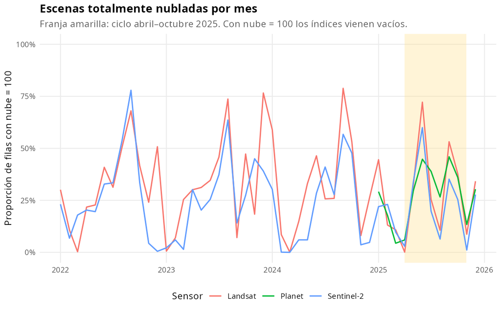

Proporción de escenas totalmente nubladas por mes.

La temporada de lluvias (mayo a octubre) coincide con el ciclo del cultivo y concentra las escenas nubladas. Es justo el periodo de la etiqueta, así que el filtro de nube pesa más ahí que en cualquier otra época del año.

## 4.2 La etiqueta

| Estado | Entren. | Predic. | Mín | Media | Mediana | Máx | Valores distintos |
| --- | --- | --- | --- | --- | --- | --- | --- |
| Hidalgo | 36 | 15 | 2.00 | 3.76 | 3.50 | 4.87 | 21 |
| Puebla | 71 | 29 | 2.15 | 4.48 | 4.52 | 5.59 | 54 |
| Tlaxcala | 31 | 15 | 2.50 | 2.98 | 3.00 | 3.50 | 3 |

Tlaxcala solo toma 3 valores distintos entre 2.5 y 3.5 t/ha. Es una característica del dato reportado, no una distribución continua, y limita lo que un modelo puede aprender dentro de ese estado.

# 5 Transformación

## 5.1 Filtro de nubosidad y ciclo

El umbral es un parámetro (`NUBE_MAX` en `00_setup.R`), igual a **30** en esta corrida (decisión del equipo; el primer KDD se corrió con 0). Se conservan observaciones con `porcentaje_nubosidad` ≤ 30, con índice presente, entre el 1 de abril y el 31 de octubre de 2025.

| Sensor | Umbral de nube | Observaciones | Mín. por parcela | Mediana por parcela | Parcelas con menos de 5 |
| --- | --- | --- | --- | --- | --- |
| Sentinel-2 | 0 | 5,688 | 14 | 29 | 0 |
| Sentinel-2 | 10 | 6,267 | 25 | 32 | 0 |
| Sentinel-2 | 30 | 6,562 | 27 | 33 | 0 |
| Landsat | 0 | 3,263 | 8 | 15 | 0 |
| Landsat | 10 | 3,360 | 8 | 16 | 0 |
| Landsat | 30 | 3,474 | 8 | 16 | 0 |
| Planet | 0 | 14,578 | 38 | 76 | 0 |
| Planet | 10 | 15,483 | 53 | 80 | 0 |
| Planet | 30 | 16,148 | 60 | 84 | 0 |

Con el umbral elegido (30) 0 parcelas quedan con menos de 5 observaciones, sumando los tres sensores. Pasar de 0 a 10 o 30 añade pocas fechas por sensor, así que el umbral cambia poco el tamaño de la muestra: sube el número de observaciones a costa de admitir escenas con algo de nube. La parcela más pobre conserva 27 fechas de Sentinel-2, 8 de Landsat y 60 de Planet.

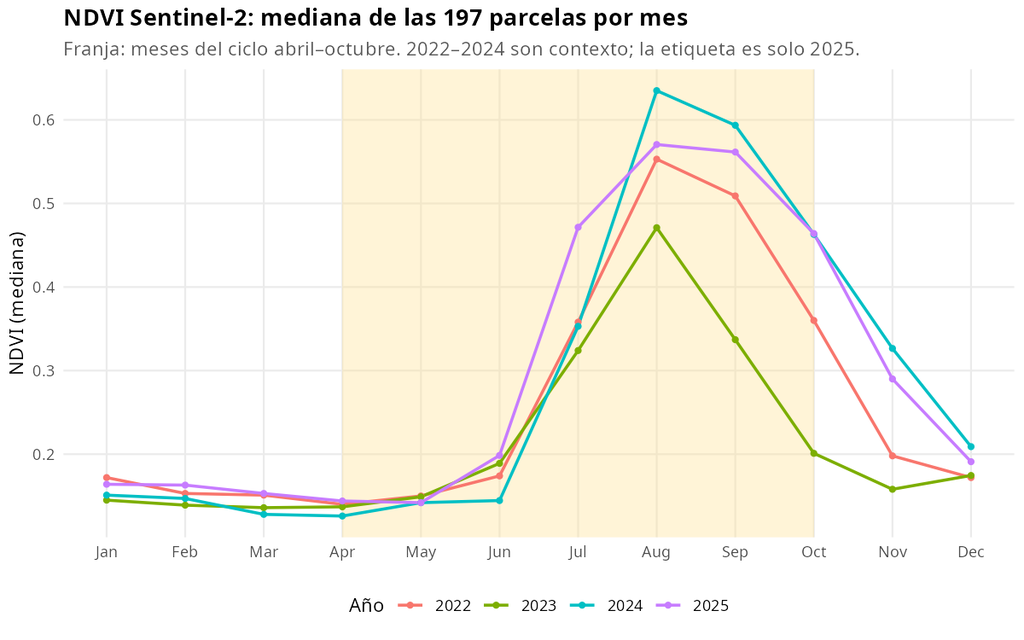

NDVI de Sentinel-2 por mes y año. Los años previos son contexto.

## 5.2 Tabla de trabajo

`analisis/datos_fira/salida/parcelas_trabajo.csv` tiene 197 filas (una por parcela) y 101 columnas. El rendimiento queda vacío en las 59 parcelas de predicción.

| Grupo | Columnas |
| --- | --- |
| Calidad | 4 |
| Clima | 7 |
| Etiqueta | 1 |
| Identificación | 2 |
| Landsat | 3 |
| Parcela | 6 |
| Planet | 23 |
| Sentinel-2 | 49 |
| Topografía | 6 |

Cada sensor mantiene sus propias columnas (`ndvi_s2_*`, `ndvi_planet_*`, `vi6t_landsat_*`). Los índices de dosel se resumen con máximo, media, integral, día del máximo y heterogeneidad interna; el NDVI además con su media por fase (mayo–julio, agosto, septiembre–octubre). El diccionario completo está en `parcelas_trabajo_diccionario.csv`.

Con el umbral de nube de esta corrida, 0 columnas tienen algún vacío (aparte del rendimiento oculto en predicción). Con nube 0, dos parcelas (`AGC_016` en agosto y `AGC_096` en septiembre–octubre) se quedaban sin observaciones limpias de Sentinel-2 en una fase; subir el umbral a 30 lo resuelve. Si vuelve a ocurrir, no se imputa.

## 5.3 Clima y topografía

| Dato | Valor |
| --- | --- |
| Parcelas | 197 |
| Píxeles CHIRPS/CHIRTS distintos (píxel principal) | 25 |
| Parcelas que tocan más de un píxel | 31 |

Las 197 parcelas caen sobre solo 25 celdas del ráster de clima. Una celda concentra 56 parcelas y otra 41. Parcelas colindantes comparten lluvia y temperatura, y ese valor sirve para distinguir zonas. Elevación y pendiente (120 m) sí varían entre parcelas, pero la pendiente describe la ladera, no el microrrelieve dentro del lote.

# 6 Relaciones con el rendimiento

## 6.1 Dónde y cuánto

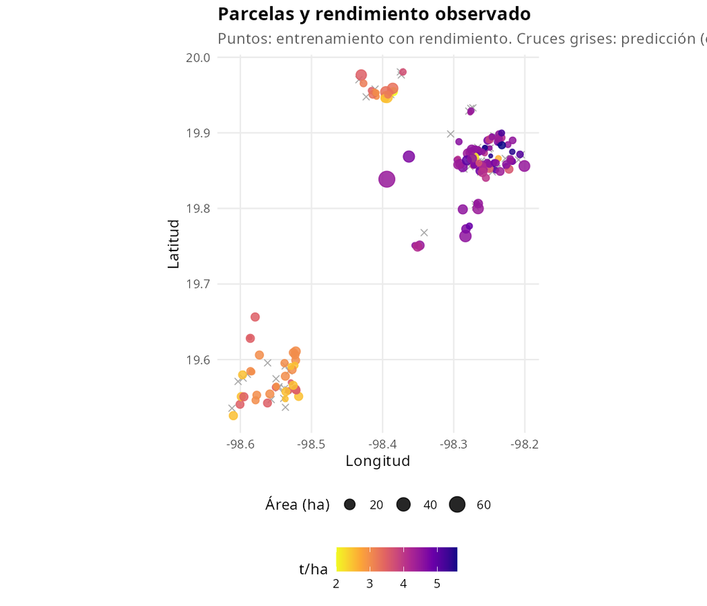

Parcelas y rendimiento observado.

| Estado | Municipio | Parcelas | Entren. | Rend. medio | Desv. est. | Área media (ha) |
| --- | --- | --- | --- | --- | --- | --- |
| Puebla | Chignahuapan | 100 | 71 | 4.48 | 0.58 | 5.0 |
| Tlaxcala | Calpulalpan | 44 | 30 | 3.00 | 0.37 | 5.7 |
| Hidalgo | Singuilucan | 23 | 16 | 3.08 | 0.43 | 8.6 |
| Hidalgo | Almoloya | 14 | 10 | 4.52 | 0.19 | 12.6 |
| Hidalgo | Cuautepec de Hinojosa | 9 | 5 | 4.60 | 0.15 | 7.2 |
| Hidalgo | Emiliano Zapata | 3 | 3 | 3.50 | 0.00 | 5.9 |
| Tlaxcala | Nanacamilpa de Mariano Arista | 2 | 1 | 2.50 |  | 7.9 |
| Hidalgo | Apan | 1 | 1 | 3.00 |  | 11.8 |
| Hidalgo | Tepeapulco | 1 | 1 | 4.45 |  | 64.3 |

| Modelo descriptivo | R² ajustado | Grupos |
| --- | --- | --- |
| Rendimiento ~ estado | 0.496 | 3 |
| Rendimiento ~ municipio | 0.667 | 9 |
| Rendimiento ~ pixel de clima | 0.660 | 23 |

El rendimiento cambia mucho entre municipios del mismo estado (Singuilucan promedia 3.08 t/ha; Almoloya, 4.52, ambos en Hidalgo). El píxel de clima explica una proporción parecida a la del municipio porque ambos parten el territorio de forma parecida. Por eso una validación cruzada con corte aleatorio sobrestimaría el desempeño: hay que cortar por municipio o por píxel.

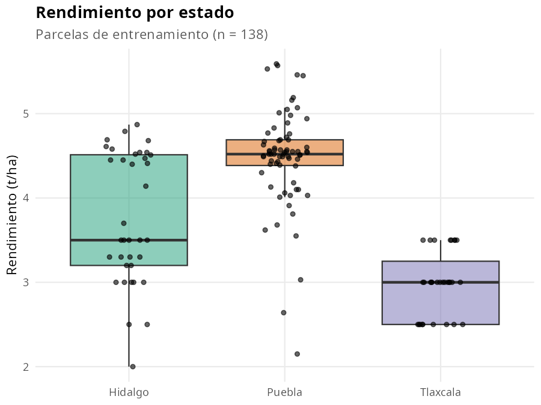

Rendimiento por estado.

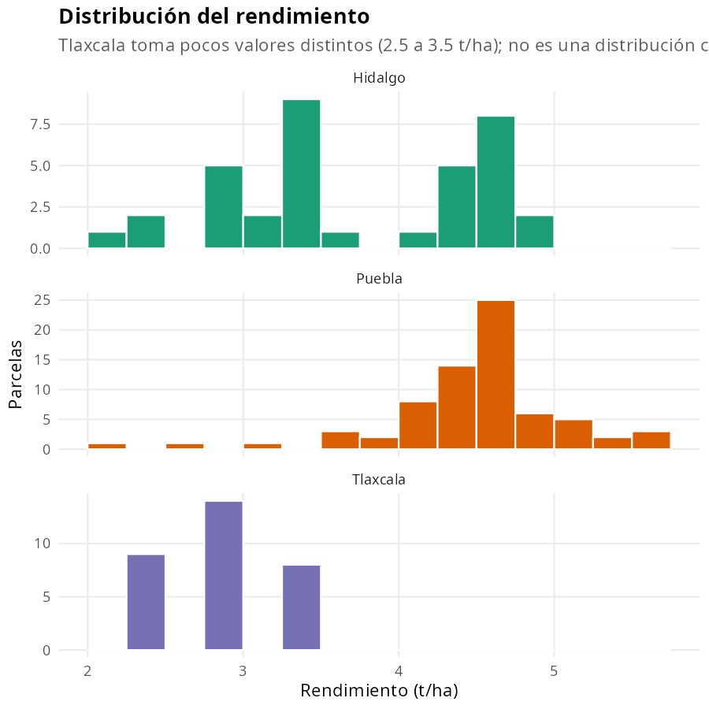

Distribución del rendimiento por estado.

## 6.2 Trayectoria del ciclo

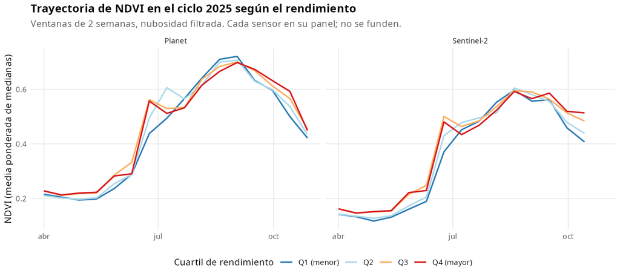

NDVI del ciclo 2025 por cuartil de rendimiento. Cada sensor en su panel.

Las trayectorias tienen la misma forma en Sentinel-2 y Planet: suelo desnudo hasta junio, subida rápida en julio, pico en agosto–septiembre y descenso en octubre. Las parcelas del cuartil de mayor rendimiento mantienen un NDVI más alto en septiembre y octubre. El máximo casi no discrimina. Por eso la tabla de trabajo incluye el NDVI medio de septiembre a octubre.

Planet da un NDVI absoluto mayor que Sentinel-2 para las mismas fechas. Son historias paralelas de la misma parcela, no una sola medición.

## 6.3 Correlaciones

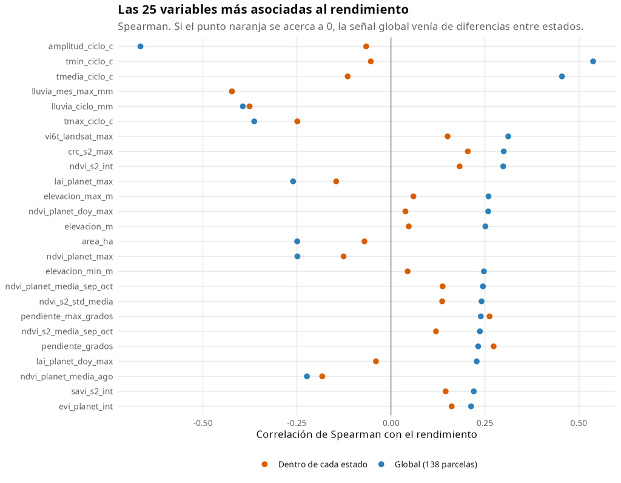

Variables con mayor correlación de Spearman con el rendimiento.

Hay dos lecturas de cada variable: la global (138 parcelas) y la que queda al restar la media de cada estado. Cuando la segunda cae a cero, la variable estaba describiendo el estado.

| Variable | Fuente | ρ global | ρ dentro del estado | p ajustado (dentro) |
| --- | --- | --- | --- | --- |
| amplitud_ciclo_c | Clima | -0.67 | -0.07 | 0.58 |
| tmin_ciclo_c | Clima | 0.54 | -0.05 | 0.64 |
| tmedia_ciclo_c | Clima | 0.46 | -0.12 | 0.35 |
| lluvia_mes_max_mm | Clima | -0.42 | -0.42 | 2.1e-05 |
| lluvia_ciclo_mm | Clima | -0.39 | -0.38 | 0.00024 |
| tmax_ciclo_c | Clima | -0.36 | -0.25 | 0.048 |
| vi6t_landsat_max | Landsat | 0.31 | 0.15 | 0.29 |
| crc_s2_max | Sentinel-2 | 0.30 | 0.20 | 0.16 |
| ndvi_s2_int | Sentinel-2 | 0.30 | 0.18 | 0.22 |
| lai_planet_max | Planet | -0.26 | -0.15 | 0.29 |
| elevacion_max_m | Topografía | 0.26 | 0.06 | 0.6 |
| ndvi_planet_doy_max | Planet | 0.26 | 0.04 | 0.7 |
| elevacion_m | Topografía | 0.25 | 0.05 | 0.67 |
| area_ha | Parcela | -0.25 | -0.07 | 0.58 |
| ndvi_planet_max | Planet | -0.25 | -0.13 | 0.32 |

| Fuente | Variable | ρ global | ρ dentro del estado |
| --- | --- | --- | --- |
| Clima | amplitud_ciclo_c | -0.67 | -0.07 |
| Landsat | vi6t_landsat_max | 0.31 | 0.15 |
| Parcela | area_ha | -0.25 | -0.07 |
| Planet | lai_planet_max | -0.26 | -0.15 |
| Sentinel-2 | crc_s2_max | 0.30 | 0.20 |
| Topografía | elevacion_max_m | 0.26 | 0.06 |

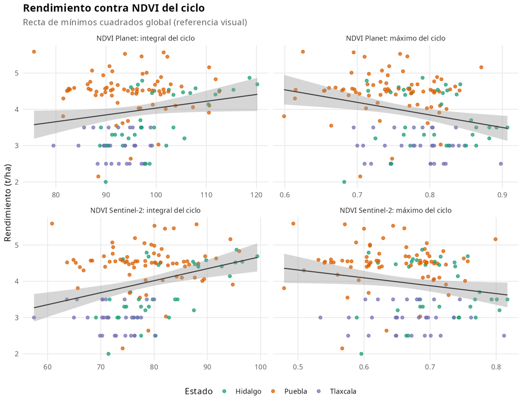

Rendimiento contra NDVI del ciclo.

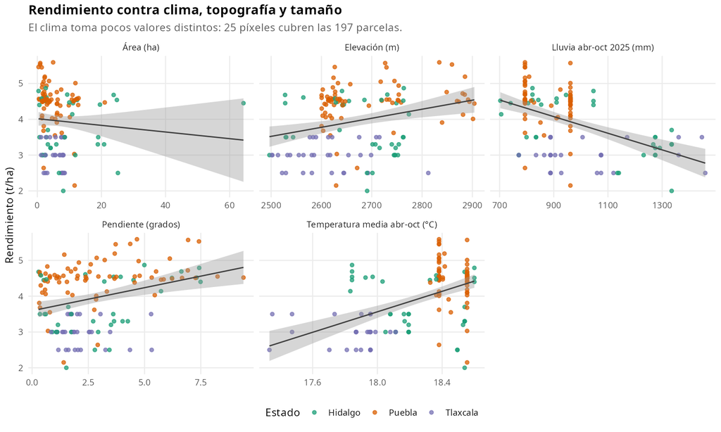

Rendimiento contra clima, topografía y área.

# 7 Patrones entre variables y parcelas

## 7.1 Redundancia

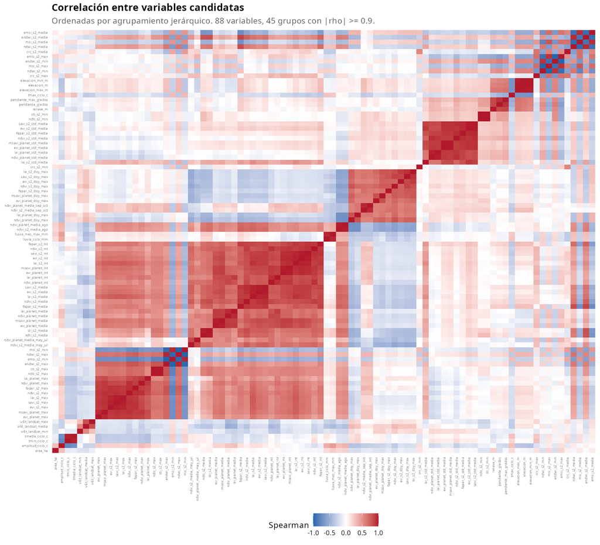

Correlación entre variables candidatas, ordenada por agrupamiento.

| Tamaño | Variables casi idénticas (\|ρ\| ≥ 0.90) |
| --- | --- |
| 7 | evi_planet_max, evi_s2_max, fapar_s2_max, lai_s2_max, msavi_planet_max, ndvi_s2_max, savi_s2_max |
| 6 | evi_planet_std_media, evi_s2_std_media, fapar_s2_std_media, msavi_planet_std_media, ndvi_s2_std_media, savi_s2_std_media |
| 5 | evi_planet_int, evi_s2_int, lai_s2_int, msavi_planet_int, savi_s2_int |
| 4 | evi_s2_media, lai_s2_media, ndvi_s2_media, savi_s2_media |
| 4 | emsi_s2_media, endwi_s2_media, msi_s2_media, ndwi_s2_media |
| 4 | emsi_s2_min, endwi_s2_max, msi_s2_min, ndwi_s2_max |
| 4 | emsi_s2_max, endwi_s2_min, msi_s2_max, ndwi_s2_min |
| 3 | elevacion_m, elevacion_max_m, elevacion_min_m |
| 2 | lluvia_ciclo_mm, lluvia_mes_max_mm |
| 2 | tmedia_ciclo_c, tmin_ciclo_c |

NDVI, EVI, SAVI, LAI y FAPAR de Sentinel-2 se comportan como una sola señal, igual que NDWI/ENDWI/MSI/EMSI en humedad y STI/NDTI en residuo. Elevación media, mínima y máxima también son prácticamente la misma variable. Para la fase de modelos, conviene un representante por grupo o un método que tolere colinealidad, y no sumar índices por su cantidad.

## 7.2 PCA exploratorio

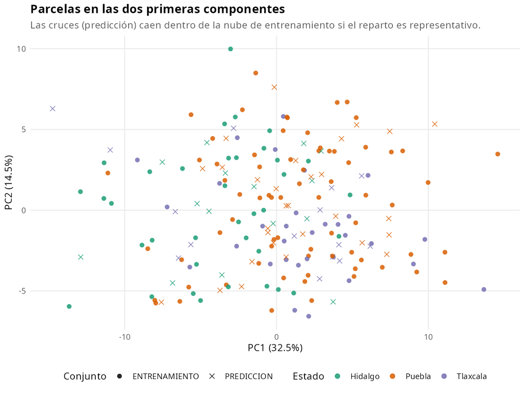

Parcelas en las dos primeras componentes.

Con las variables estandarizadas, las primeras 5 componentes explican 73 % de la varianza. Las parcelas de predicción caen dentro de la nube de las de entrenamiento: el reparto oficial no deja zonas sin representación en este espacio.

La única componente con relación clara con el rendimiento es la quinta (ρ = -0.62). Está cargada por amplitud térmica, temperatura mínima y elevación, es decir, por el eje que separa a Tlaxcala de Puebla. Confirma la lectura de arriba: la señal más fuerte es territorial.

## 7.3 Perfiles de parcela

Se agruparon las parcelas con un método jerárquico (Ward) sobre las componentes principales, sin usar el rendimiento.

| Perfil | Parcelas | Hidalgo | Puebla | Tlaxcala | Entren. | Predic. | Rend. medio | Desv. est. |
| --- | --- | --- | --- | --- | --- | --- | --- | --- |
| P1 | 66 | 24 | 34 | 8 | 46 | 20 | 4.00 | 0.92 |
| P2 | 39 | 20 | 11 | 8 | 26 | 13 | 4.06 | 0.64 |
| P3 | 33 | 1 | 28 | 4 | 24 | 9 | 4.13 | 0.78 |
| P4 | 59 | 6 | 27 | 26 | 42 | 17 | 3.74 | 0.91 |

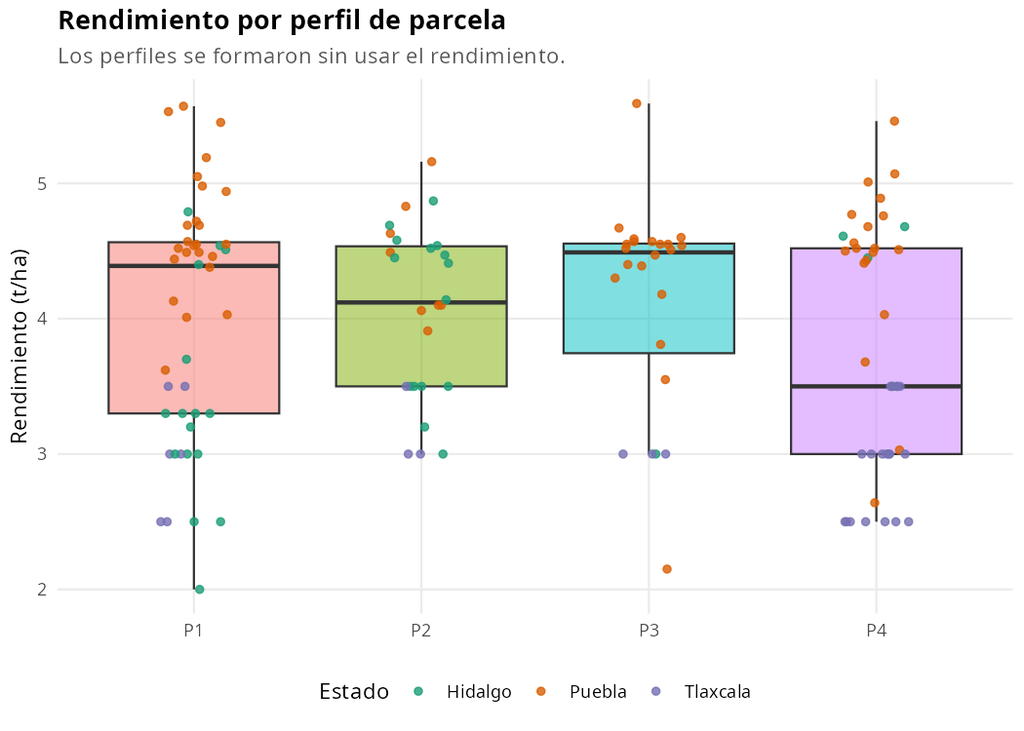

Rendimiento por perfil de parcela.

Los perfiles se distinguen sobre todo por estado, y sus rendimientos medios se parecen entre sí. La prueba de Kruskal-Wallis no detecta diferencias (p = 0.383). Los datos no forman clases naturales de productividad; el rendimiento depende de una combinación de variables, no de una etiqueta de grupo. Es una advertencia: la ubicación explica mucho entre municipios, pero dentro de un mismo municipio no alcanza para distinguir parcelas.

# 8 Respuesta preliminar a las preguntas guía del reto

# 9 Qué queda para la fase de modelos

- **Tabla base:** `parcelas_trabajo.csv`, 197 filas.
- **Validación:** cortar por municipio o por píxel de clima, no de forma aleatoria. Los vecinos comparten territorio y manejo.
- **Reducir redundancia** con un representante por familia (por ejemplo `ndvi_s2_int`, `ndvi_s2_media_sep_oct`, `crc_s2_media`, `lluvia_ciclo_mm`, `pendiente_grados`).
- **Sensores separados:** Sentinel-2, Landsat y Planet no se funden. Planet cubre solo 2025, lo que coincide con la etiqueta.
- **Tlaxcala:** rendimiento con tres valores; considerar su error por separado.
- **No usar** `lon`, `lat` ni `pixel_clima` como variables sin decidir antes el riesgo de aprender únicamente la ubicación.
- **Pendiente para después:** los años 2022–2024 (antecedente climático y de vegetación) no entraron a la tabla; están extraídos en los intermedios por si se decide usarlos.

# 10 Cómo reproducir

Desde la raíz del repositorio:

```bash
bash analisis/correr.sh
```

Ejecuta en orden `analisis/datos_fira/R/01_seleccion.R` a `06_patrones.R` y compila este informe en `analisis/datos_fira/salida/kdd.html`. Los paquetes necesarios y la nota sobre GDAL están en `analisis/README.md`.